# SpotifyR Workshop R User Group Finland

Marc Eixarch

3/26/2023

# Prerequisites

- Make sure to follow the instructions given in our [github page](https://github.com/eivicent/r-meetups-hki/tree/main/2023_03_28_SpotifyR) to **get your Spofity client ID and Secret**
- **Install spotifyR library** `install.packages('spotifyr')`

During the workshop we will use the following libraries

```r
# Core
library(tidyverse)

# Optional
library(ggExtra)
```

Let’s load the library and test our credentials work fine. There are several ways to use and store our credentials. The recommended option is via environment variables. You can do this in two different ways

1. Manually input them in the code (commented in the code below). This works fine for working locally in your computer if you don’t have to share the code. You can either include them in the main code or source them through another file.
2. Store them as permanent system variables in your `Renviron` file. Much better and secure, but needs extra configuration if you have several Spotify Apps.

```r
library(spotifyr)
# Uncomment the line below and add you client credentials for manual input
#Sys.setenv(SPOTIFY_CLIENT_ID = 'XXXXXX')
#Sys.setenv(SPOTIFY_CLIENT_SECRET = 'XXXXXX')
access_token <- get_spotify_access_token()
```

**Important parenthesis**: it seems Spotify has been doing changes recently to its online documentation. Some functions in the package point to specific url that have been now renamed and return a 404 Error, invalidating the whole function. This is a hacky workaround to avoid that error until there is a proper fix. This already happened in the past (see stack overflow [thread](https://stackoverflow.com/questions/69649706/error-while-trying-to-extract-spotify-data-using-r)), so I just updated it to the new url.

**In summary**, if you get an error when running some functions, you can run the snippet below to try to solve it. Otherwise, you can just skip it and ignore it.

```r
# scopes <- function() {
#   xml2::read_html("https://developer.spotify.com/documentation/web-api/concepts/scopes/") %>%
#   rvest::html_elements("code") %>% rvest::html_text() %>%
#   unique()
# }
#
# assignInNamespace("scopes", scopes, ns = "spotifyr")
```

Back to work… Once we have the `access_token` ready, we can test it works fine by running the code below

```r
my_playlists <- spotifyr::get_my_playlists()
my_playlists %>%
  select(name, owner.display_name, tracks.total) %>%
  head(6)
```

|  | name | owner.display_name | tracks.total |
| --- | --- | --- | --- |
| 1 | M | Marc | 1221 |
| 2 | Almost M | Marc | 395 |
| 3 | Brasil | Marc | 58 |
| 4 | Long runs | Marc | 39 |
| 5 | Your Top Songs 2022 | Spotify | 101 |
| 6 | La Guitarra | Marc | 11 |

If the code below didn’t return anything because you have not created or saved any playlists, you can use the following code to get a summary of Spotify main music categories.

```r
spotifyr::get_categories()$name
```

```
 [1] "Top Lists"        "EQUAL"            "At Home"          "Romance"
 [5] "Pop"              "Hip-Hop"          "Rock"             "Mood"
 [9] "Party"            "Dance/Electronic" "Metal"            "Workout"
[13] "Chill"            "Decades"          "Indie"            "Sleep"
[17] "Focus"            "Jazz"             "R&B"              "Classical"
```

# Intro to the library

The [package](https://github.com/charlie86/spotifyr) was created Charlie Thompson in 2017 and is currently in open source, actively maintained by Charlie *et al.* Spotifyr is an R wrapper for pulling track audio features and other information from Spotify’s Web API in bulk.

### Functions

Run `help("spotifyr")` or `ls("package:spotifyr")` to explore all spotifyR functions and help pages. In short, with this package and through the API we can access to several data fetching functions as well as manipulations functions that interact with your Spotify profile.

- Retrieve information related to artists. Eg `get_artist_audio_features` or `get_track_audio_features` to get all track features of a specific artist or set of tracks
- Retrieve tracks from given playlists or user-based stats `get_playlist_tracks` or `get_my_top_artists_or_tracks`
- Interact with your own profile. Eg `add_tracks_to_playlist` to add tracks to an existing playlist you own or even `pause_my_playback()` to stop your current playback (if active)

### Features

One of the most interesting attributes of this API is the amount of metadata or attributes you can get through it. Besides from the expected tracks metadata such as popularity, albums, length or artists you can get intrinsic music features. See the [Spotify Web API documentation](https://developer.spotify.com/documentation/web-api/reference/#/operations/get-several-audio-features) for a detailed description.

- `danceability` shows how suitable a track is for dancing
- `energy` is a measure from 0.0 to 1.0 and represents a perceptual measure of intensity and activity
- `instrumentalness` predicts whether a track contains no vocals
- `valence` measures from 0.0 to 1.0 describing the musical positiveness conveyed by a track
- `liveness` detects the presence of an audience in the recording
- `key`, `mode`, `tempo` and `time_signature` are estimations of musical properties of the specific track

# Hands-on Part 1

### Exploratory Analysis on Artists

Let’s start by exploring how different artists have evolved over time in different Albums. We first need to pick a set of artists you’d like to explore. You can do it manually by specifying the artists names or collect them automatically through the package by calling `get_my_top_artists_or_tracks(limit = 2)`

```r
#my_artists <- get_my_top_artists_or_tracks(limit = 2) %>% pull(name)
my_artists <- c('Beyonce', 'AC/DC')
```

Let’s get now all audio features by those artists by calling `get_artist_audio_features`. Note that this function only allows to input one artist, probably to avoid saturating the API calls. We can use `lapply` and `bind_rows` to run the function for several artists. I recommend starting with very few artists, eg 2 to maximum 4, as otherwise it might take too long to run.

You can see all audio features obtained by running `colnames(my_artists_track_features)` before modifying the data frame. For now we are going to filter by the ones we’d like to use in our first example.

```r
my_artists_track_features <- bind_rows(lapply(my_artists, get_artist_audio_features, market = 'US'))

my_artists_track_features <- my_artists_track_features %>%
  select(artist_name, album_release_year, danceability, energy, valence, liveness, tempo, duration_ms, track_name, album_name, track_id, artist_id)
```

Note that we have added the parameter `market` as per package recommendation to avoid duplicates.

Let’s jump now into some summary stats of our artists albums.

```r
my_album_summary_stats <- my_artists_track_features %>%
  group_by(artist_name, album_release_year, album_name) %>%
  summarise(across(where(is.numeric), mean),
            tracks = n(),
            .groups = 'drop')

head(my_album_summary_stats)
```

| artist_name | album_release_year | album_name | danceability | energy | valence | liveness | tempo | duration_ms | tracks |
| --- | --- | --- | --- | --- | --- | --- | --- | --- | --- |
| AC/DC | 1976 | Dirty Deeds Done Dirt Cheap | 0.5432222 | 0.7456667 | 0.5232222 | 0.2388333 | 122.7977 | 265454.3 | 9 |
| AC/DC | 1976 | High Voltage | 0.6081111 | 0.6784444 | 0.4299333 | 0.1013444 | 126.1197 | 295042.6 | 9 |
| AC/DC | 1977 | Let There Be Rock | 0.4493750 | 0.7925000 | 0.4431250 | 0.1959375 | 143.1623 | 307744.8 | 8 |
| AC/DC | 1978 | Powerage | 0.4710000 | 0.8346667 | 0.4437778 | 0.1386444 | 140.3422 | 266022.0 | 9 |
| AC/DC | 1979 | Highway to Hell | 0.4747000 | 0.8752000 | 0.5537000 | 0.3074100 | 137.3684 | 250039.6 | 10 |
| AC/DC | 1980 | Back In Black | 0.4559000 | 0.8469000 | 0.5923000 | 0.3292500 | 129.7218 | 252811.6 | 10 |

Note that we would like to get rid of Live albums and focus only on studio recordings. This could be done by trying to match keywords such as ‘Live’ or ‘Tour’ in the album name. But we can use one of Spotify’s features to do it as well, `liveness`. As suggested by the API documentation, a value above 0.8 provides strong likelihood that the track is live. Let’s check it with our data.

```r
my_album_summary_stats %>%
  filter(liveness > 0.5) %>%
  select(artist_name, album_release_year, album_name, liveness)
```

| artist_name | album_release_year | album_name | liveness |
| --- | --- | --- | --- |
| AC/DC | 1978 | If You Want Blood You've Got It (Live) | 0.9207000 |
| AC/DC | 1992 | Live | 0.8836429 |
| AC/DC | 1992 | Live (Collector's Edition) | 0.8608261 |
| AC/DC | 2012 | Live at River Plate | 0.9352632 |
| Beyoncé | 2010 | I Am...World Tour | 0.7828400 |
| Beyoncé | 2019 | HOMECOMING: THE LIVE ALBUM | 0.6206213 |

For our example artists, all albums with an average liveness score larger than 0.5 is live, so we can use this rule to exclude them from both data frames.

```r
live_albums <- my_album_summary_stats %>%
  filter(liveness > 0.5) %>%
  pull(album_name)

my_artists_track_features <- my_artists_track_features %>%
  filter(!album_name %in% live_albums)

my_album_summary_stats <- my_album_summary_stats %>%
  filter(!album_name %in% live_albums)
```

We’d also like to get rid of *special edition* albums, as they are basically copies of other albums plus some extra tracks. This time we will go for a bit more hacky solution and just remove any album containing “edition” on its name.

```r
my_album_summary_stats %>%
  filter(grepl('edition', tolower(album_name)) == TRUE)
```

[output not shown]

```r
special_edition_albums <- my_album_summary_stats %>%
  filter(grepl('edition', tolower(album_name)) == TRUE)%>%
  pull(album_name)

my_artists_track_features <- my_artists_track_features %>%
  filter(!album_name %in% special_edition_albums)

my_album_summary_stats <- my_album_summary_stats %>%
  filter(!album_name %in% special_edition_albums)
```

Let’s now try to get some insights out of those albums. We can start by getting a summary of the average album energy for each artist over time.

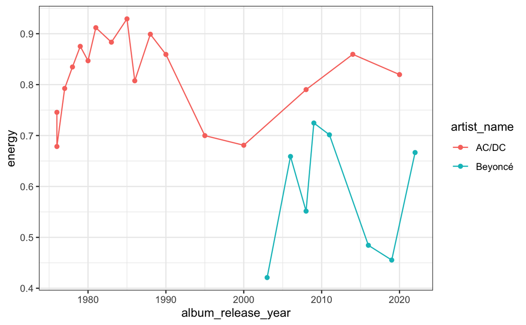

```r
my_album_summary_stats %>%
  ggplot(aes(x = album_release_year, y = energy, color = artist_name)) +
  geom_line() +
  geom_point() +
  theme_bw()
```

Surprised? AC/DC’s music seem to be more energetic than Beyoncé’s in average. It’s also clear that AC/DC stopped releasing albums for some years and when they came back their energy was lower as well.

We can generalise the chart above with two extra additions:

- Add one screen for each feature we’d like to investigate
- In order to have a “comparable” x-axis, let’s use the album number (as count of albums from the artists up to that point), instead of the year of release.

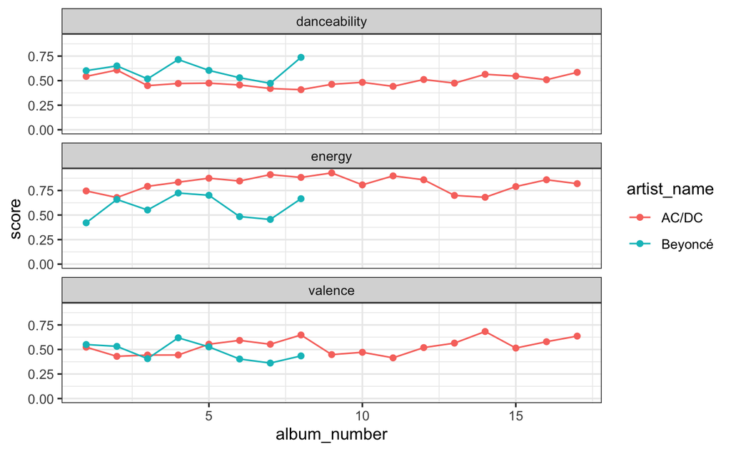

```r
my_album_summary_stats %>%
  group_by(artist_name) %>%
  mutate(album_number = row_number(album_release_year)) %>%
  ungroup() %>%
  pivot_longer(cols = !c(artist_name, album_release_year, album_name, album_number),
               names_to = 'feature',
               values_to = 'score') %>%
  filter(feature %in% c('danceability', 'energy', 'valence')) %>%
  ggplot(aes(x = album_number, y = score, color = artist_name)) +
  geom_line() +
  geom_point() +
  facet_wrap(.~feature, ncol=1) +
  coord_cartesian(ylim = c(0, NA)) +
  theme_bw()
```

Lastly, let’s check if there’s any interesting cluster for their songs in the space energy - valence. For that we’ll use the `my_artists_track_features` data frame that we have obtained at the previously.

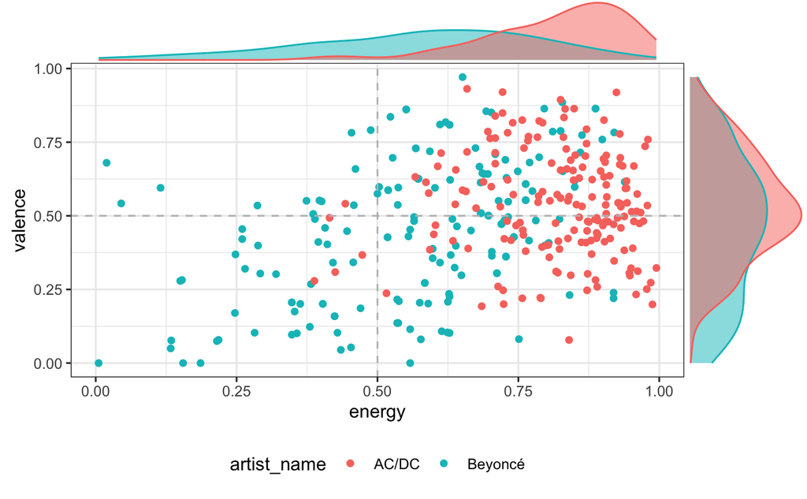

```r
p <- my_artists_track_features %>%
  ggplot(aes(x = energy, y = valence, color = artist_name)) +
  geom_point() +
  geom_hline(yintercept = 0.5, color = 'grey', linetype = 'dashed') +
  geom_vline(xintercept = 0.5, color = 'grey', linetype = 'dashed') +
  theme_bw() +
  theme(legend.position = "bottom")

ggExtra::ggMarginal(p, type = "density", groupColour = TRUE, groupFill = TRUE)
```

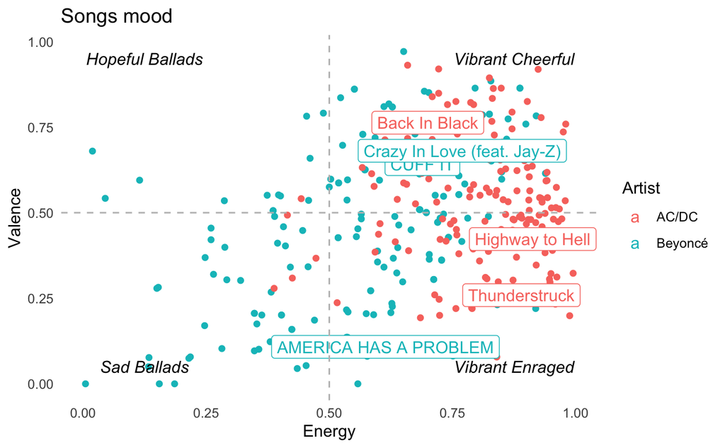

```r
top_tracks <- bind_rows(lapply(unique(my_artists_track_features$artist_id), get_artist_top_tracks))

top_tracks %>%
  select(id, popularity) %>%
  right_join(my_artists_track_features, by=c('id'='track_id')) %>%
  group_by(artist_name) %>%
  mutate(rank_top_song = row_number(desc(popularity))) %>%
  ggplot(aes(x = energy, y = valence, color = artist_name)) +
  geom_point() +
  geom_label(aes(label = ifelse(rank_top_song<=3, track_name, NA))) +
  geom_hline(yintercept = 0.5, color = 'grey', linetype = 'dashed') +
  geom_vline(xintercept = 0.5, color = 'grey', linetype = 'dashed') +
  annotate('text', 0.25 / 2, 0.95, label = "Hopeful Ballads", fontface = "italic") +
  annotate('text', 1.75 / 2, 0.95, label = "Vibrant Cheerful", fontface = "italic") +
  annotate('text', 1.75 / 2, 0.05, label = "Vibrant Enraged", fontface = "italic") +
  annotate('text', 0.25 / 2, 0.05, label = "Sad Ballads", fontface = "italic") +
  theme_minimal() +
  theme(panel.grid.major = element_blank(), panel.grid.minor = element_blank()) +
  labs(x='Energy', y='Valence', color='Artist', title = 'Songs mood')
```

Remember this classification as we might use it later on! To end this first exploratory section let’s summarise in a boxplot the main music attributes for each artists. We will take the occasion to personalise a bit the ggplot theme and make it look a bit more in line with Spotify colors by tweaking the theme.

```r
spotify_colors <- list(
  dark_green = '#1DB954',
  light_green = '#1ed760',
  black = '#191414',
  ligth_grey = '#b3b3b3',
  white = '#FFFFFF'
)

theme_spotify <- function(){ #based on monokai theme https://github.com/datarootsio/artyfarty
  color.background = spotify_colors$black
  color.grid.major = spotify_colors$white
  color.text = spotify_colors$dark_green
  color.text.2 = spotify_colors$light_green
  color.axis = spotify_colors$white

  theme_bw(base_size=13, base_family='Tahoma') +
    theme(

      panel.background=element_rect(fill=color.background, color=color.background),
      plot.background=element_rect(fill=color.background, color=color.background),
      panel.border=element_rect(color=color.background),

      panel.grid.major=element_line(color=color.grid.major,size=.4, linetype=2),
      panel.grid.minor=element_blank(),
      panel.grid.major.x=element_blank(),
      axis.line.x=element_line(color=color.grid.major, size=1),
      axis.line.y=element_line(color=color.grid.major, size=1),
      axis.ticks=element_line(color=NA),

      legend.background = element_rect(fill=color.background),
      legend.key = element_rect(fill=color.background, color=NA),
      legend.text = element_text(size=rel(.8),color=color.text.2),#color.axis.title),
      legend.title = element_text(color=color.text, face = 'bold'),

      plot.title=element_text(color=color.text, size=rel(1.2), hjust=.5, face = 'bold'),
      axis.text.x=element_text(size=rel(.95),color=color.text),
      axis.text.y=element_text(size=rel(.95),color=color.text),
      axis.title.x=element_text(size=rel(1),color=color.text, vjust=0),
      axis.title.y=element_text(size=rel(1),color=color.text, vjust=1.25)
    )
}

monokai_palette <- c(
  "#F92672",
  "#FD971F",
  "#F4BF75",
  "#A6E22E",
  "#A1EFE4",
  "#66D9EF",
  "#AE81FF",
  "#CC6633"
)
```

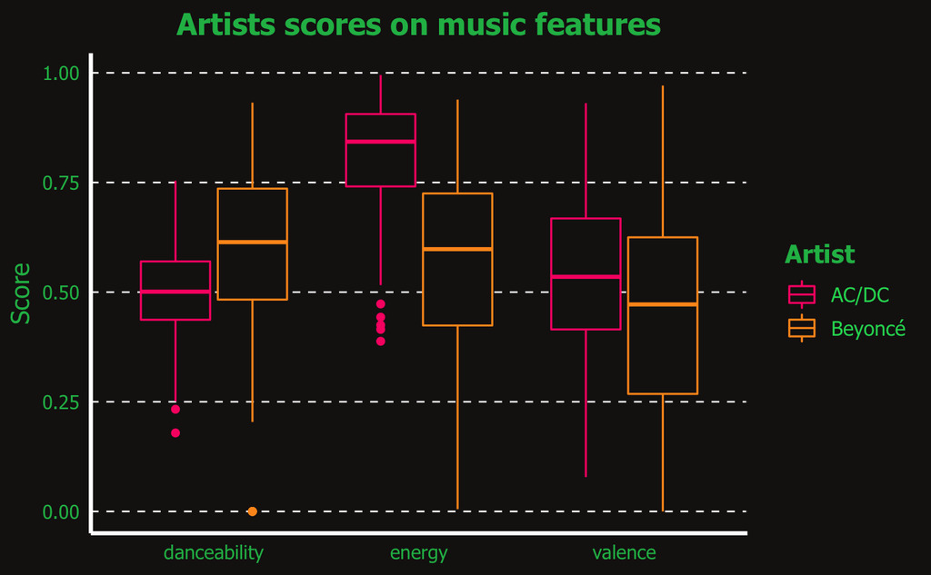

```r
my_artists_track_features %>%
  pivot_longer(cols = !c(track_name, artist_name, album_release_year, album_name, track_id, artist_id),
               names_to = 'feature',
               values_to = 'score') %>%
  filter(feature %in% c('danceability', 'energy', 'valence')) %>%
  ggplot(aes(x = feature, y = score, color = artist_name)) +
  geom_boxplot(fill = spotify_colors$black) +
  labs(y='Score', x=NULL, color = 'Artist', title = 'Artists scores on music features') +
  scale_color_manual(values=monokai_palette) +
  theme_spotify()
```

The chart above confirms something that might be quite intuitive for the listeners. AC/DC songs are much more consistent among them and have less variance, while Beyoncé’s music might cover a wider range of emotions or dynamics.

You can try to get similar insights from the artists you picked!

# Hands-on Part 2

### Create customised recommended Playlists

Let’s start by exploring a bit our own data.

```r
my_top_artists <- get_my_top_artists_or_tracks(
  type = "artists",
  limit = 50, #the maximum
  time_range = "medium_term" #about 6 months history
)

my_top_artists %>%
  select(name, genres, popularity)
```

|  | name | genres | popularity |
| --- | --- | --- | --- |
| 1 | Vulfpeck |  | 63 |
| 2 | The Tallest Man On Earth |  | 56 |
| 3 | El Petit De Cal Eril |  | 33 |
| 4 | Pau Vallvé |  | 43 |
| 5 | Xarim Aresté |  | 25 |
| 6 | Camaron De La Isla |  | 53 |
| 7 | Chet Atkins |  | 47 |
| 8 | Los Estanques |  | 35 |
| 9 | Twanguero |  | 28 |
| 10 | El Pony Pisador |  | 39 |

[output cut: 40 more lines]

What are my top genres?

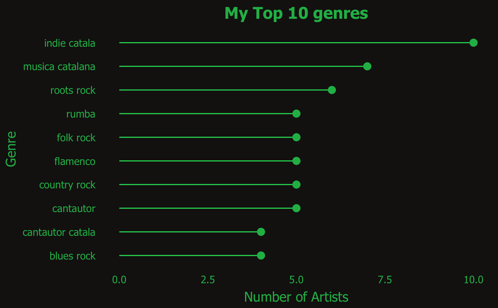

```r
my_top_artists %>%
  unnest(genres) %>%
  group_by(genres) %>%
  summarise(artists = n()) %>%
  arrange(desc(artists)) %>%
  head(10) %>%
  arrange(artists) %>%
  mutate(genres = factor(genres, genres)) %>%
  ggplot(aes(x=genres, y = artists)) +
  geom_segment(aes(x=genres, xend=genres, y=0, yend=artists),
               color = spotify_colors$light_green) +
  geom_point(size = 3, color = spotify_colors$dark_green) +
  coord_flip() +
  theme_spotify() +
  theme(panel.grid.major = element_blank(),
        #panel.grid.minor.x = element_line(color='white',size=.4, linetype=2),
        axis.line.x = element_blank(),
        axis.line.y = element_blank(),
        ) +
  labs(x='Genre', y='Number of Artists', title = 'My Top 10 genres')
```

How mainstream am I?

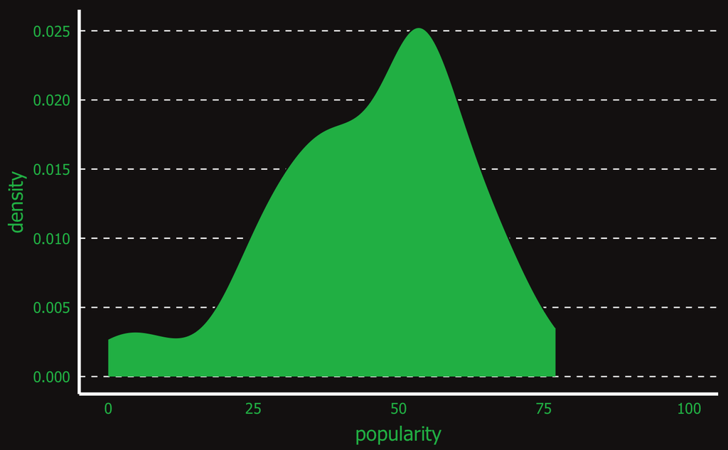

```r
my_top_artists %>%
  ggplot(aes(x=popularity)) +
  geom_density(color = spotify_colors$black, fill = spotify_colors$dark_green) +
  coord_cartesian(xlim = c(0,100)) +
  theme_spotify()
```

You can compare to your neighbor…

To end with, we will create a playlist based on our recommendations using `get_recommendations`. The function has many parameters which allows to be quite creative with the conditions we want to apply.

We can feed it with three different *seeds*, which will trigger specific recommendations: `seed_artists`, `seed_genres` and `seed_tracks`. And then give max, min and target values for several of the audio features we have been exploring. Let’s try to create a playlist made of sad ballads and based on our top 5 artists. How would you approach it?

```r
my_sad_ballads <- get_recommendations(
  seed_artists = head(my_top_artists, 5)$id,
  max_energy = 0.5,
  max_valence = 0.5
)
```

Now that we have the tracks, let’s create the empty playlist.

```r
create_playlist(
  user_id = 'your_spotify_username',
  name = 'My Sad Ballads',
  description = 'Generated with R!'
)
```

And now populate it with our recommendations

```r
add_tracks_to_playlist(
  playlist_id = 'your_new_playlist_list', #get it from the output of the previous function
  uris = my_sad_ballads$id
)
```

And that’s all for today’s workshop! This was just an introduction to the functions, much more can be done. Hope you enjoyed and hope this triggered some curiosity to generate some visualisations and insights by yourselves.